# Proyecto

Mariana Corte Rodriguez

2023-10-16

# Introducción

La lechuga *(Lactuca sativa L.)* es una planta herbacea anual perteneciente a la familia Compositae. Es una planta que presenta un elevado contenido de agua del 90 al 95%, su valor nutricional se resalta por el contenido de minerales y vitaminas.

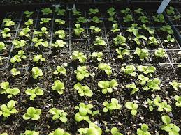

[Liga con informacion sobre la germinacion para las semillas de lechuga](https://www.traxco.es/blog/produccion-agricola/cultivo-de-lechuga)

Se realizó un estudio para medir la efectividad de un bioestimulante en la germinación de las plántulas de lechuga y se comparo con el crecimiento con el uso de un fertilizante a dos temperaturas distintas para determinar el mejor tratamiento y temperatura optima, mediante un analisis estadistico.

```r
# Librerias:

library(dplyr)
library(tidyr)
library(readr)
library(tidyverse)
library(car)
library(tinytex)
library(devtools)
devtools::install_github('yihui/tinytex')
# Set de datos que se utilizara y que se cargo al ambiente utilizando la libreria readr:

Set_datos <- read.csv("~/CursoR/CursoRgit/Proyectos/Set_datos_nuevo.csv")
Estanque_plantas <- read.csv("~/CursoR/CursoRgit/Proyectos/Estanque_plantas.csv")
```

## Analisis estadistico

Antes de comenzar a realizar el analisis estadistico del set de datos es necesario seguir los siguientes pasos para asegurarnos que los datos cumplan con todas las suposiciones:

- Normalización
- Transformación
- Balancear
- Homogeneidad de varianzas

**1. Normalización y Transformacion:** Los datos a analizar deben seguir una distribución normal por lo que se realizará el test de shapiro, un histograma y un qqplot. Codigos:

- shapiro.test()
- hist()
- qqnorm()

Si los datos de las variables a analizar no estan normalizados se deberán transformar siguiendo las normas dependiendo de como esten distribuidos los datos.

```r
# Test de Shapiro

for (i in 3:ncol(Set_datos)) {
  shapiro <- shapiro.test(Set_datos[,i])
  normal <- ifelse(shapiro[["p.value"]]>0.05, "YES", "NO")
  print(c(i,normal))
}
```

```
## [1] "3"   "YES"
## [1] "4"  "NO"
## [1] "5"  "NO"
```

```r
# Se utilizo la funcion "FOR LOOP IF ELSE" para resolver de una sola vez cuales de las tres variables a nalizar si cumplen con el test de shapiro.Se obtuvo como resultados que la variable de longitud de raiz si cumple con el test por que el valor de pvalue si es mayor a 0.05 y la respuesta que imprimio fue "YES", mientras que la longitud de tallo y el numero de hojas no cumplen.
```

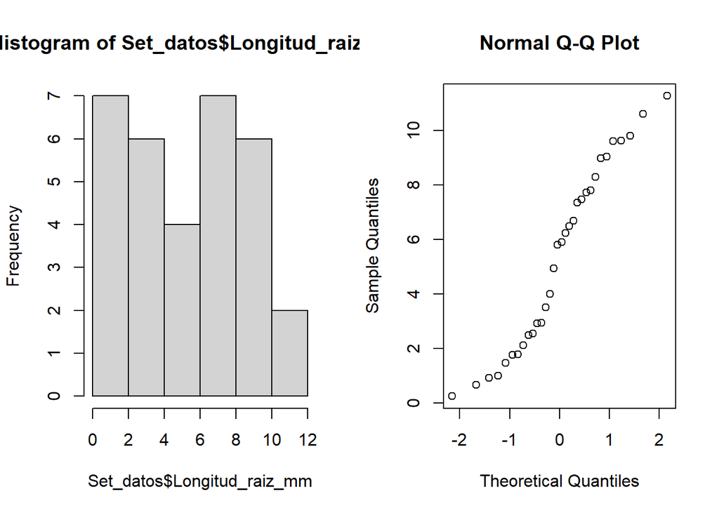

```r
# Histograma y qqplot para Longitud de Raiz

par(mfrow=c(1,2))
hist(Set_datos$Longitud_raiz_mm)
qqnorm(Set_datos$Longitud_raiz_mm)
```

```r
# Ambos graficos se observan normalizados por lo que no es necesario transformar los datos para la variable de Longitud_raiz_mm.
```

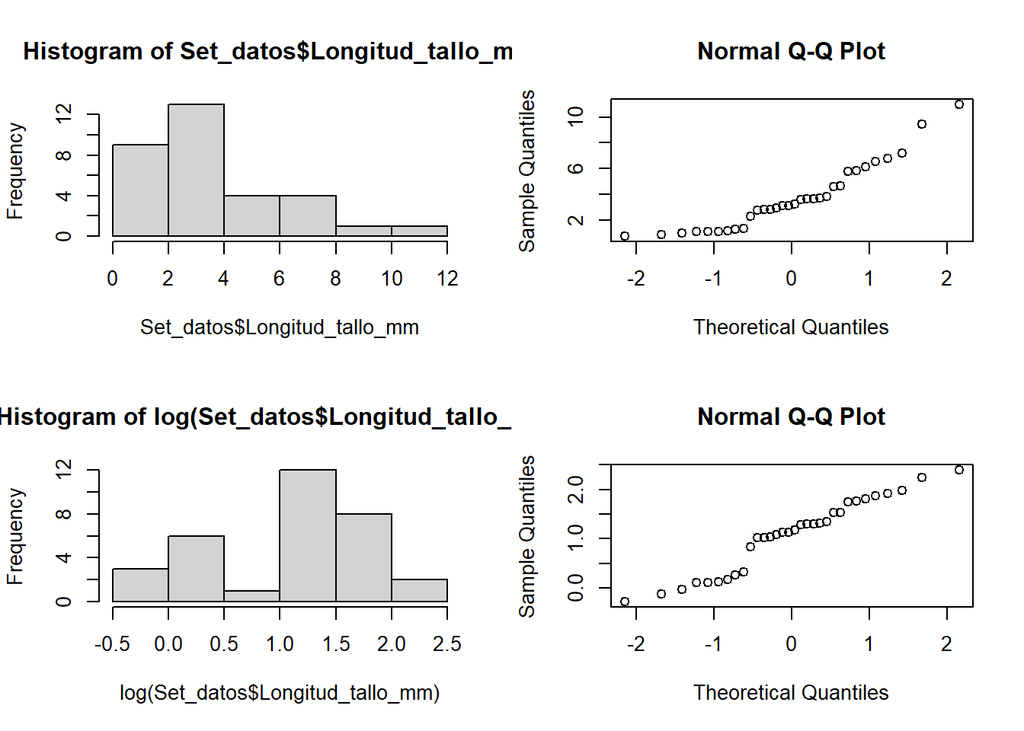

```r
# Histograma, qqplot y test de shapiro para la variable Longitud de Tallo

par(mfrow=c(2,2)) # se acomodan los graficos en 2 fila y 2 columnas para antes y despues de transformar
hist(Set_datos$Longitud_tallo_mm)
qqnorm(Set_datos$Longitud_tallo_mm)
hist(log(Set_datos$Longitud_tallo_mm))
qqnorm(log(Set_datos$Longitud_tallo_mm))
```